# Лабораторная работа № 2

Динамические модели SIR и Лотки–Вольтерры

Куокконен Дарина Андреевна

Российский университет дружбы народов имени Патриса Лумумбы

НФИбд-01-23

2026-08-29

# Вводная часть

## Две модели показывают разные типы динамики

**Цель:** исследовать пороговую эпидемическую динамику и циклическое взаимодействие популяций средствами Julia.

- SIR: переход от роста инфекции к затуханию;
- Лотка–Вольтерра: периодические колебания жертв и хищников;
- численное решение систем ОДУ методом `Tsit5`;
- параметрические эксперименты, графики и тесты;
- QMD, выполненные IPYNB, отчёт и презентация.

## Проект продолжает конвейер лабораторной №1

`Literate.jl` → `Julia` → `Jupyter` → `Quarto` → `Git`

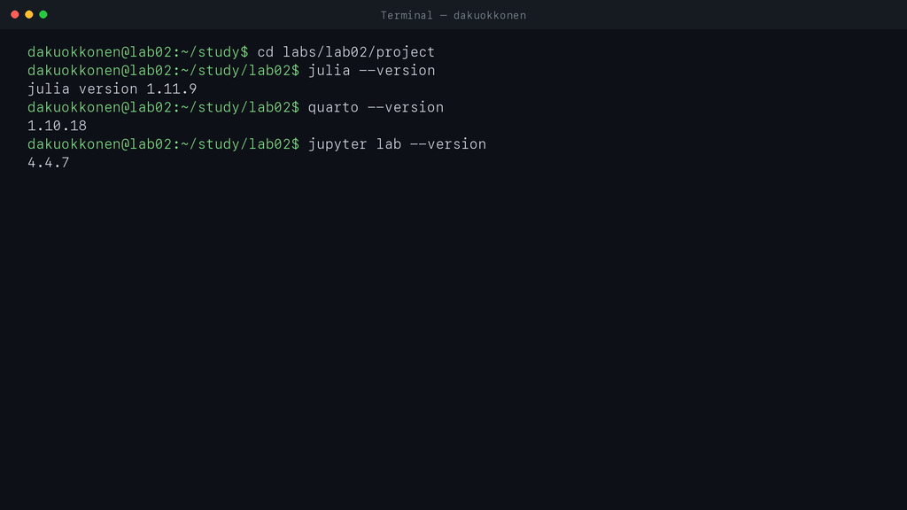

- Julia 1.11.9
- DifferentialEquations.jl
- DrWatson.jl
- Plots.jl
- IJulia и Quarto

Версии закреплены в `Manifest.toml`.

# Теоретическая часть

## В SIR порог задаёт репродуктивное число

$$\frac{dS}{dt}=-\beta c\frac{SI}{N}, \qquad
\frac{dI}{dt}=\beta c\frac{SI}{N}-\gamma I,$$

$$\frac{dR}{dt}=\gamma I, \qquad
R_0=\frac{\beta c}{\gamma}, \qquad
R_e(t)=R_0\frac{S(t)}{N}.$$

- $S+I+R=N$ сохраняется;
- при $R_0>1$ инфекция сначала распространяется;
- после пересечения $R_e=1$ число инфицированных убывает.

## Система Лотки–Вольтерры образует замкнутые орбиты

$$\frac{dx}{dt}=\alpha x-\beta xy, \qquad
\frac{dy}{dt}=\delta xy-\gamma y.$$

$$(x^*,y^*)=\left(\frac{\gamma}{\delta},\frac{\alpha}{\beta}\right)=(30,5).$$

Первый интеграл

$$H=\delta x-\gamma\ln x+\beta y-\alpha\ln y$$

должен оставаться постоянным вдоль численной траектории.

# Выполнение работы

## Один модуль содержит обе математические модели

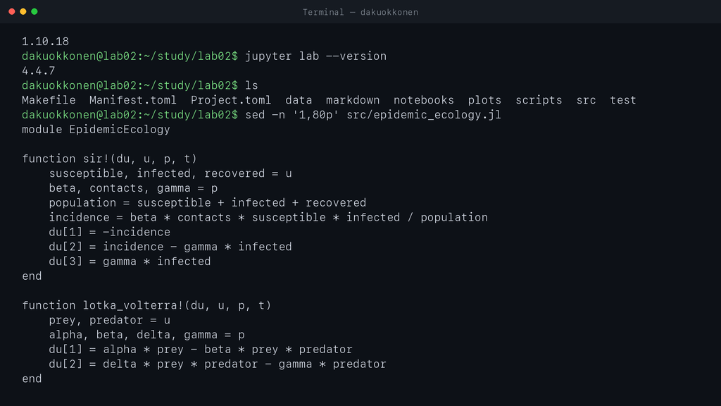

Общие функции:

- `sir!`;
- `lotka_volterra!`;
- вычисление $R_0$ и $R_e$;
- равновесие;
- первый интеграл.

Сценарии и тесты используют один источник формул.

## Literate.jl создаёт три согласованных представления

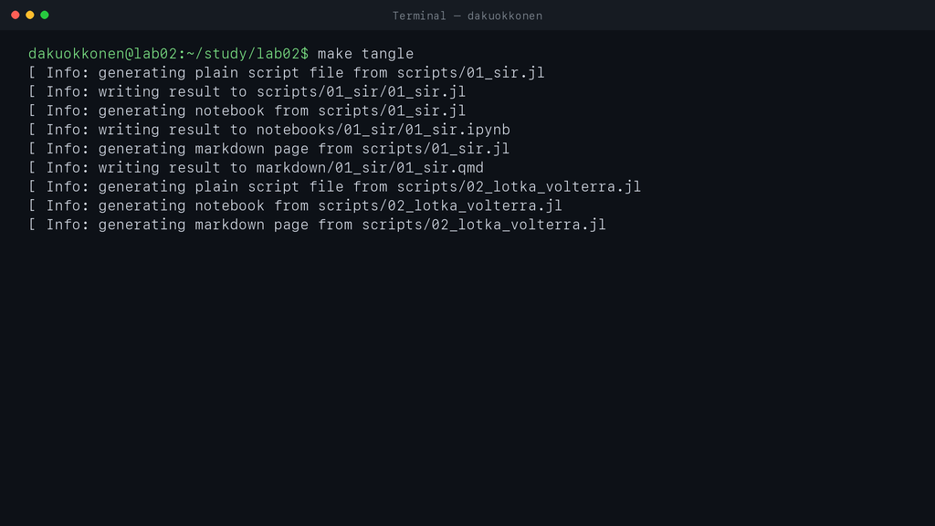

Для каждой модели создаются:

- чистый Julia-скрипт;
- Quarto QMD;
- Jupyter IPYNB.

Ноутбуки выполняются с ядром лабораторной №2.

# Результаты SIR

## При $R_0=2$ пик возникает на 17,5-й день

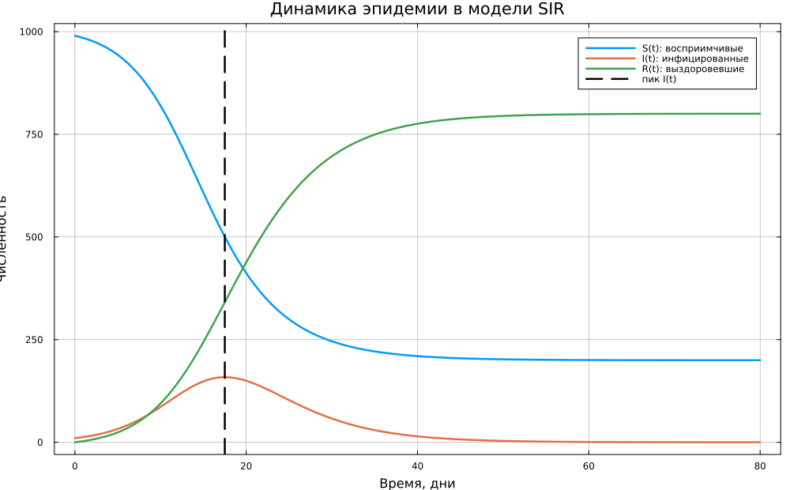

| Показатель | Значение |
| --- | --- |
| $R_0$ | 2,0000 |
| $I_{max}$ | 158,4512 |
| $t_{peak}$ | 17,5 |
| $R(80)$ | 800,1424 |

Дрейф $S+I+R$ меньше $8\cdot10^{-13}$.

## Пересечение $R_e=1$ объясняет начало спада

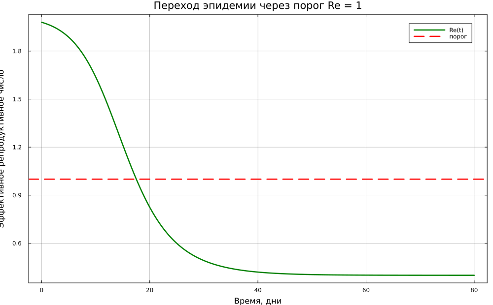

- в начале $R_e\approx1{,}98$;
- восприимчивые постепенно выбывают;
- $R_e<1$ с 17,6-го дня;
- после этого $dI/dt<0$.

Пороговая величина совпадает с наблюдаемым пиком.

## Число контактов управляет высотой и временем пика

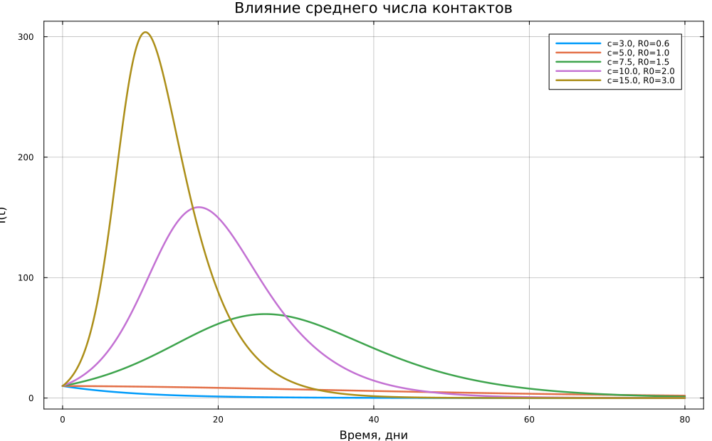

| $c$ | $R_0$ | $I_{max}$ |
| --- | --- | --- |
| 3 | 0,6 | 10,0 |
| 5 | 1,0 | 10,0 |
| 7,5 | 1,5 | 69,7 |
| 10 | 2,0 | 158,5 |
| 15 | 3,0 | 303,8 |

Чем выше $R_0$, тем раньше и выше эпидемическая волна.

# Результаты Лотки–Вольтерры

## Рост жертв опережает рост хищников

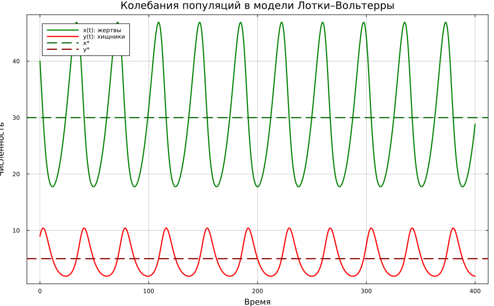

- равновесие: $(30,5)$;
- период: 37,6889;
- жертвы: 17,75–46,89;
- хищники: 1,90–10,41.

Максимум хищников следует за максимумом жертв.

## Фазовая траектория подтверждает циклический режим

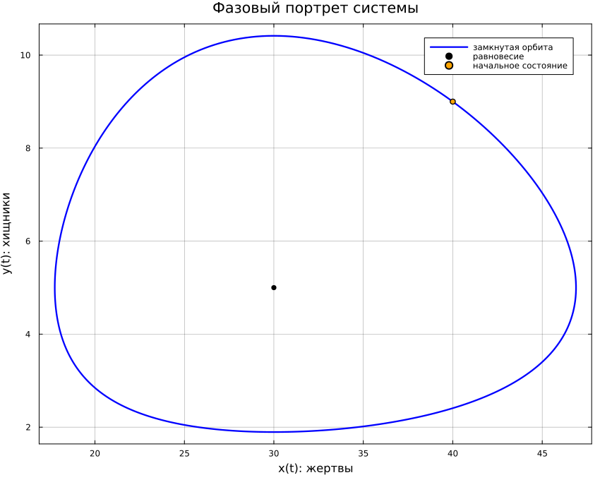

Начальное состояние $(40,9)$ не является равновесием.

Траектория:

- остаётся в положительном квадранте;
- окружает точку $(30,5)$;
- возвращается к исходной окрестности;
- не приближается к предельному состоянию.

## Первый интеграл сохраняется с высокой точностью

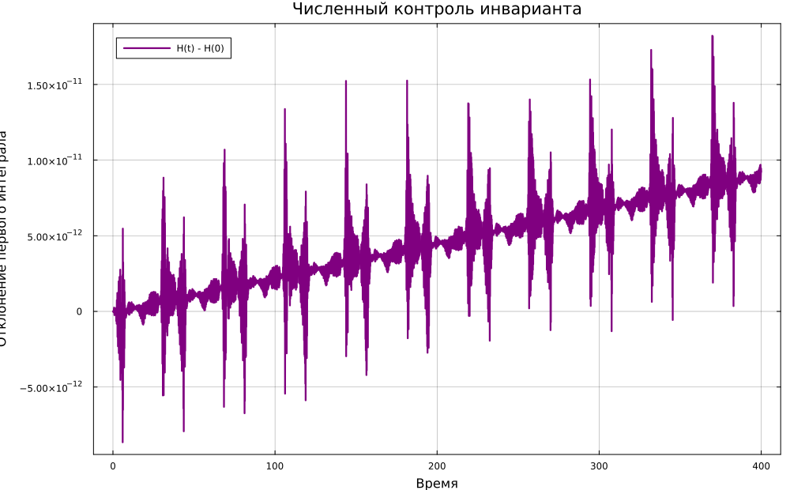

$$\max_t |H(t)-H(0)|
\approx 1{,}82\cdot10^{-11}.$$

Малый дрейф подтверждает корректность решения на интервале $0\leq t\leq400$.

## Начальные условия меняют амплитуду, но не равновесие

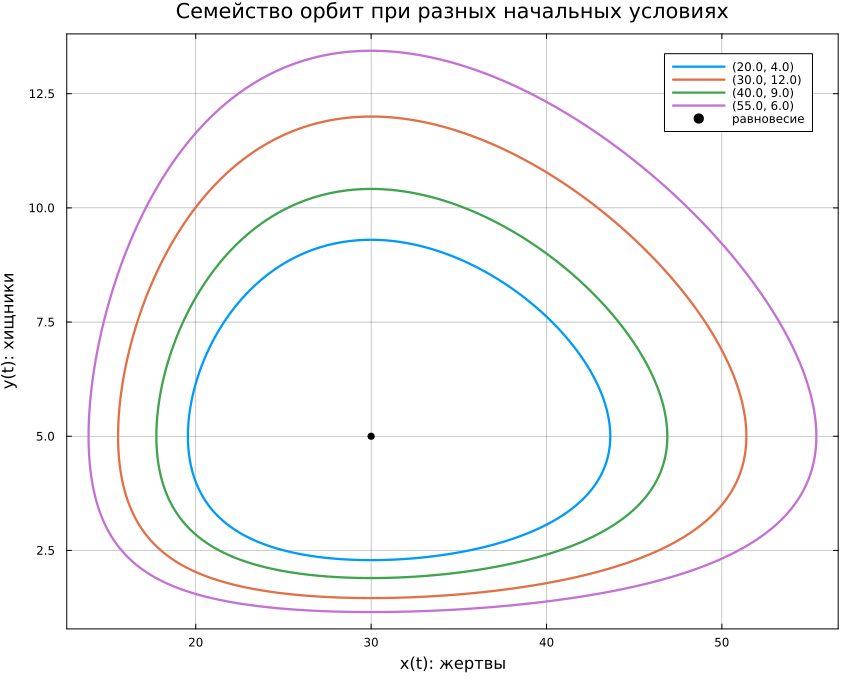

Исследованы состояния:

- $(20,4)$;
- $(30,12)$;
- $(40,9)$;
- $(55,6)$.

Все орбиты окружают одну точку $(30,5)$, но отличаются диапазонами популяций.

# Проверка и документация

## Оба ноутбука выполнены в JupyterLab

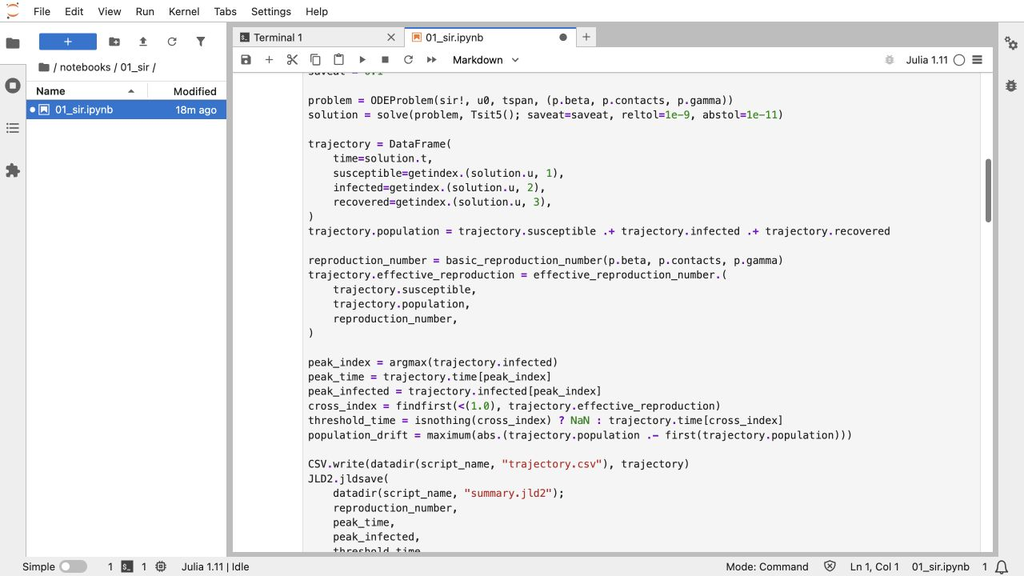

Модель SIR.

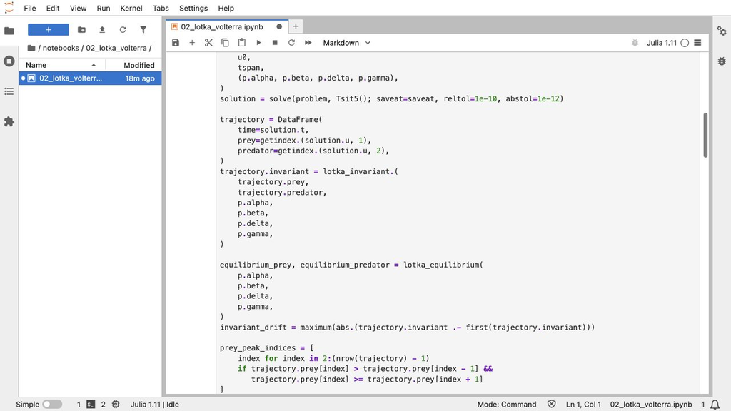

Модель Лотки–Вольтерры.

## Десять тестов проверяют формулы и инварианты

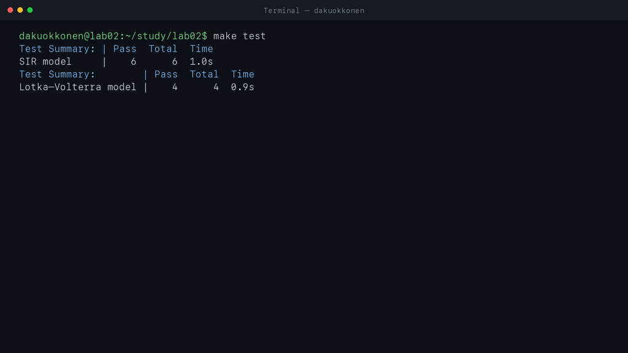

- 6 проверок SIR;
- 4 проверки Лотки–Вольтерры;
- сохранение $S+I+R$;
- положительность решений;
- стационарная точка;
- сохранение $H(x,y)$.

**Все тесты пройдены.**

# Заключение

## Обе модели согласуются с теоретическими свойствами

- SIR показала пороговый переход, пик инфекции и последующее затухание;
- увеличение числа контактов повышает и ускоряет эпидемический пик;
- система Лотки–Вольтерры образует периодические замкнутые орбиты;
- численные инварианты сохраняются с погрешностью $10^{-11}$–$10^{-13}$;
- подготовлены Julia, CSV, графики, QMD, выполненные IPYNB и тесты;
- отчёт и презентация собраны из проверенных результатов.

**Лабораторная работа №2 выполнена полностью.**